# Map of votes for FIFA Best Coach of 2020 Votes

*January 4, 2021*

## 1. Topics

- Read table from PDF with *tabulizer*
- Use google fonts with *showtext*
- Plot data on maps
- libraries used: tabulizer, dplyr, janitor, ggplot2, showtext

## 2. Get data from pdf into R with tabulizer

I was surprised to see Jürgen Klopp win the FIFA 2020 best coach award ahead of Hans-Dieter Flick. I therefore wanted to study where the votes in favour of Klopp came from. On FIFA’s website I found a PDF with all the votes. FIFA obviously don’t provide a nice csv, but only this PDF. However, a quick search for an R function that would allow to **extract data from a table in a PDF** was successful. The answer is the `extract_tables()` function from the [tabulizer](https://cran.r-project.org/web/packages/tabulizer/vignettes/tabulizer.htm) library. Let’s see it in action.

```r
# Load library
library("tabulizer")
# Load file
file <- if (file.exists("votes.pdf")) {
  "votes.pdf"
} else {
  "https://resources.fifa.com/image/upload/men-s-coach.pdf?cloudid=fewk8jzbkqxgjdthofsb"
}
# Extract the data from the PDF
data_from_pdf<- extract_tables(file)
head(data_from_pdf[[1]])
```

```
##      [,1]      [,2]             [,3]              [,4]
## [1,] "Vote"    "Country"        "Name"            "First (5 points)"
## [2,] "Captain" "Afghanistan"    "Farshad Noor"    "JÃ¼rgen Klopp"
## [3,] "Captain" "Albania"        "Etrit Berisha"   "JÃ¼rgen Klopp"
## [4,] "Captain" "Algeria"        "Riyad Mahrez"    "Marcelo Bielsa"
## [5,] "Captain" "American Samoa" "Nicky Salapu"    "JÃ¼rgen Klopp"
## [6,] "Captain" "Andorra"        "Marc Pujol Pons" "Hans-Dieter Flick"
##      [,5]                [,6]
## [1,] "Second (3 points)" "Third (1 point)"
## [2,] "Hans-Dieter Flick" "Marcelo Bielsa"
## [3,] "Hans-Dieter Flick" "Marcelo Bielsa"
## [4,] "JÃ¼rgen Klopp"     "Zinedine Zidane"
## [5,] "Zinedine Zidane"   "Marcelo Bielsa"
## [6,] "JÃ¼rgen Klopp"     "Marcelo Bielsa"
```

This looks promising. With `extract_tables(file)` we were able to extract the tables from the PDF. The tables are stored in a list of character matrices. Let’s now convert these list elements into one big data frame.

```r
# Append list of matrices to one data frame
df<-data.frame(do.call("rbind", data_from_pdf) )
head(df)
```

```
##        X1             X2              X3                X4                X5
## 1    Vote        Country            Name  First (5 points) Second (3 points)
## 2 Captain    Afghanistan    Farshad Noor     JÃ¼rgen Klopp Hans-Dieter Flick
## 3 Captain        Albania   Etrit Berisha     JÃ¼rgen Klopp Hans-Dieter Flick
## 4 Captain        Algeria    Riyad Mahrez    Marcelo Bielsa     JÃ¼rgen Klopp
## 5 Captain American Samoa    Nicky Salapu     JÃ¼rgen Klopp   Zinedine Zidane
## 6 Captain        Andorra Marc Pujol Pons Hans-Dieter Flick     JÃ¼rgen Klopp
##                X6
## 1 Third (1 point)
## 2  Marcelo Bielsa
## 3  Marcelo Bielsa
## 4 Zinedine Zidane
## 5  Marcelo Bielsa
## 6  Marcelo Bielsa
```

Very good! Let’s do some cleaning.

## 3. Cleaning the data

```r
# Load libraries
library("dplyr")
library("janitor")
# Remove first frame and assign names
df<-df%>%
   # Convert first row to column names
    row_to_names(row_number = 1)%>%
   # Rename columns
    rename(region=Country,p5=contains("First"),p3=contains("Second"),p1=contains("Third"))%>%
   # Create a new column with Klopp and Flick voets
    mutate(Klopp=case_when(p5=="JÃ¼rgen Klopp"~5    ,p3=="JÃ¼rgen Klopp"~3    ,p1=="JÃ¼rgen Klopp"~1,TRUE ~0),
           Flick=case_when(p5=="Hans-Dieter Flick"~5,p3=="Hans-Dieter Flick"~3,p1=="Hans-Dieter Flick"~1,TRUE ~0))%>%
  # Select variables that we need
    select(-p1,-p3,-p5,-Name)
head(df)
```

```
##      Vote         region Klopp Flick
## 1 Captain    Afghanistan     5     3
## 2 Captain        Albania     5     3
## 3 Captain        Algeria     3     0
## 4 Captain American Samoa     5     0
## 5 Captain        Andorra     3     5
## 6 Captain         Angola     1     5
```

Good! This looks reasonable. I have not create a map for a while, so let us create a map. We need to adjust some of the region names before we can create a map. We also need to collapse Northern Ireland, England, Wales, and Scotland to United Kingdom.

```r
# Collapse UK votes to one
uk<-df%>%
    filter(region%in%c("England","Wales", "Northern Ireland", "Scotland"))%>%
    group_by(Vote)%>%
    summarise(Klopp=sum(Klopp),Flick=sum(Flick))%>%
    mutate(region="UK")
# Append UK to original dataset
df<-rbind(df,uk)
# Change country names (this is a bit ad hoc)
df<-df%>%
    mutate(region=case_when(region=="Chinese Taipei"~"Taiwan",
                            region=="China PR"~"China",
                            region=="Congo"~"Republic of Congo",
                            region=="Congo DR"~"Democratic Republic of the Congo",
                            region=="IR Iran"~"Iran",
                            region=="Antigua and Barbuda"~"Antigua",
                            region=="CÃ´te d'Ivoire"~"Ivory Coast",
                            region=="Korea Republic"~"South Korea",
                            region=="Korea DPR"~"North korea",
                            region=="Trinidad and Tobago"~"Trinidad",
                            region=="Republic of Ireland"~"Ireland",
                            region=="Mozambique"~"Mayotte",
                            region=="Eswatini"~"Swaziland",
                            TRUE~region))
```

In the data we have votes from the captain and coach of the national team and from a media representative. We are just going to focus on the sum of the difference in votes for Klopp and the votes for Flick across these three.

```r
# Sum difference in votes
md<-df%>%
   mutate(dif=Klopp-Flick)%>%
   group_by(region)%>%
   summarise(difference=sum(dif))
head(md)
```

```
## # A tibble: 6 x 2
##   region         difference
##   <chr>               <dbl>
## 1 Afghanistan             1
## 2 Albania                 9
## 3 Algeria                -1
## 4 American Samoa         10
## 5 Andorra               -12
## 6 Angola                 -8
```

Excellent! We have a dataset with two columns. The first column contains the country name. The second column the vote difference.

## 4. Let’s prepare the fonts.

Getting non-standard fonts into my charts in R has always been a pain for me. Especially on Windows systems. It seems to work a lot easier on Linux systems. Now I am on a Windows system and it was time to check whether there was a new convenient solution. It turns out that [showtext](https://cran.rstudio.com/web/packages/showtext/vignettes/introduction.html) has the potential of becoming a game changer. Let’s just follow the default example and add a google font:

```r
# Load library
library("showtext")
## Add google font
font_add_google("Schoolbell", "bell")
showtext_auto()
```

## 5. It is finally time for the map

We have the dataset with the fonts. We have the fonts. Now we need just need a dataset with the values for the polygons. We use `map_data()` from *ggplot2* for that.

```r
# Load library
library("ggplot2")
# Extract Map data
world_map <- map_data("world")
# Merge map data to data on votes
mapdata <- merge(md, world_map, by = "region",all=TRUE)
# Cleaning (remove Antarcatica and sort the data)
mapdata<-mapdata%>%
        filter(!(region %in% c("Antarctica")))%>%
        arrange(region,order)
```

And finally it is time for ggplot to do its work:

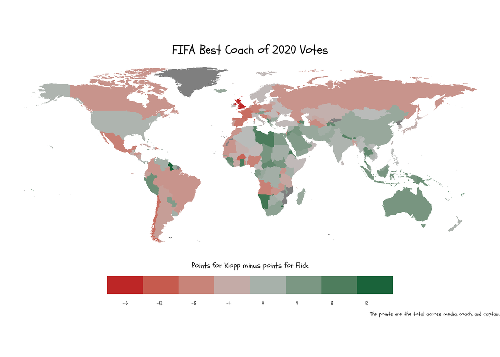

```r
ggplot(mapdata, aes(x = long, y = lat,group = group)) +
  geom_polygon(aes(fill=difference))+
  theme_void()+  coord_quickmap()+
  scale_fill_gradientn(breaks=seq(-16,13,4),labels=seq(-16,13,4),
                       colours=c("#bd2626", "grey", "#1a633a"))+
  theme(legend.position = "bottom",
        legend.text = element_text(family = "bell"),
        legend.title = element_text(family = "bell",size=15),
        plot.caption= element_text(family = "bell",size=11),
        plot.title = element_text(hjust=0.5,size=25, family = "bell"))+
  guides(fill = guide_colourbar(ticks = FALSE,
         title.position = "top", label.hjust = .5,
         title.hjust = 0.5,nbin=8, raster=F, barwidth=20,
         label.position = "bottom"))+
  labs(fill="Points for Klopp minus points for Flick",
       title="FIFA Best Coach of 2020 Votes",
       caption="The points are the total across media, coach, and captain.")
```

Voila.